# Estadística Avanzada Actividad 4

Fernando Antonio Barbeiro Campos - fbarbeiro@uoc.edu

16 June, 2018

# 1. Preprocesado

## 1.1. Carga de datos

Cargar el fichero de datos “Fumadores.csv”.

```r
df <- read.csv("data/Fumadores.csv")
head(df)
```

```
##       AE Tipo
## 1 4.0100   NF
## 2 4.8772   NF
## 3 4.2927   NF
## 4 4.9475   NF
## 5 4.1266   NF
## 6 4.1926   NF
```

## 1.2. Tipos de datos

Consultar los tipos de datos de las variables y si es necesario, aplicar las conversiones apropiadas. Averiguar posibles inconsistencias en los valores de Tipo o AE. En caso de que existan inconsitencias, corregidlas.

```r
# Buscando por valores NA
print(unlist(lapply(df, function(x) any(is.na(x)))))
```

```
##    AE  Tipo
## FALSE FALSE
```

```r
# Reunindo los tipos de variables e imprimindo
res <- sapply(df, class)
kable(data.frame(variables=names(res),clase=as.vector(res)))
```

| variables | clase |
| --- | --- |
| AE | numeric |
| Tipo | factor |

```r
summary(df) # se nota (Other) en Tipo, deberíamos tener solo 6 categorías
```

```
##        AE             Tipo
##  Min.   :1.038   FI     :20
##  1st Qu.:2.519   FM     :20
##  Median :2.954   FP     :20
##  Mean   :3.074   NF     :19
##  3rd Qu.:3.627   FL     :16
##  Max.   :5.284   NI     :16
##                  (Other): 8
```

```r
unique(df$Tipo) # Claramente el problema ha sido detectado - 2 letras minusculas
```

```
## [1] NF FP NI ni FL fL FM FI
## Levels: FI fL FL FM FP NF ni NI
```

```r
df <- as.data.frame(sapply(df, toupper))
# Aunque va enseñar solo 2 decimales, R mantiene el número como él era inicialmente
df$AE <- as.numeric(as.character(df$AE))

print(head(df$AE))
```

```
## [1] 4.0100 4.8772 4.2927 4.9475 4.1266 4.1926
```

```r
str(df)
```

```
## 'data.frame':    119 obs. of  2 variables:
##  $ AE  : num  4.01 4.88 4.29 4.95 4.13 ...
##  $ Tipo: Factor w/ 6 levels "FI","FL","FM",..: 5 5 5 5 5 5 5 5 5 5 ...
```

## 1.3. Realizar un análisis descriptivo de la muestra en su totalidad en relación a la variable AE

Recordando que la estadística descriptiva se trata de resumir los datos de una muestra (en vez de extraer conclusiones).

```r
kable(summary(df)[,1], # 1 posicion AE
      digits=2, align='l', caption="Estadística descriptiva de la variable AE", col.names = "AE")
```

Estadística descriptiva de la variable AE

| AE |
| --- |
| Min. :1.038 |
| 1st Qu.:2.519 |
| Median :2.954 |
| Mean :3.074 |
| 3rd Qu.:3.627 |
| Max. :5.284 |

## 1.4. Analizar los datos según el tipo de fumador

Mostrar el número de personas en cada tipo de fumador, la media de AE de cada tipo de fumador y un gráfico que muestre esta media. Se recomienda ordenar el gráfico de menos a más AE.

Luego, se debe representar un boxplot donde se muestre la distribución de AE por cada tipo. Para calcular la media o otras variables para cada tipo de fumador, podéis usar las funciones **summarize** y **group_by** de la libreria **dplyr** que os serán de gran utilidad. Para realizar la visualización de los datos, podéis usar la función **ggplot** de la librería **ggplot2**.

```r
library(ggplot2) # ggplot
category <-  as.data.frame(table(df$Tipo))
category
```

```
##   Var1 Freq
## 1   FI   20
## 2   FL   19
## 3   FM   20
## 4   FP   20
## 5   NF   19
## 6   NI   21
```

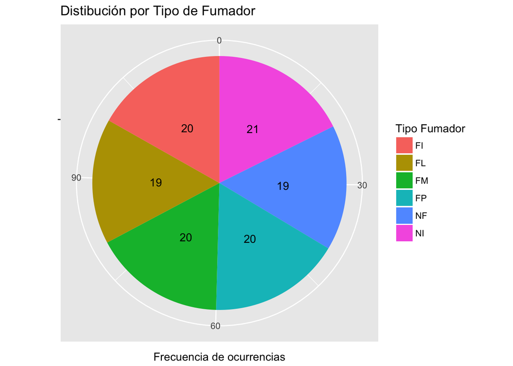

```r
p <- ggplot(category, aes(x = '', y = Freq, fill = factor(Var1)) ) + geom_bar(width = 1,stat="identity") + coord_polar(theta = "y") +
geom_text(aes(label = Freq), position = position_stack(vjust = 0.5)) + ggtitle("Distibución por Tipo de Fumador")

p + labs(fill = "Tipo Fumador", x ="", y = "Frecuencia de ocurrencias")
```

```r
###### - distribucion ended ####################

r2 <- setNames(aggregate(df[, c("AE")], list(df$Tipo), mean), c("Tipo", "Media"))
r2 <- r2[order(r2$Media),]
r2
```

```
##   Tipo    Media
## 1   FI 2.456500
## 3   FM 2.687775
## 2   FL 2.773679
## 4   FP 3.118690
## 6   NI 3.206190
## 5   NF 4.240605
```

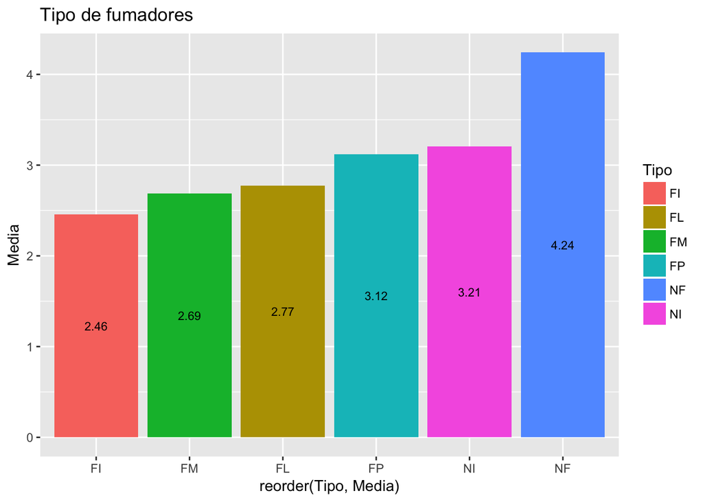

```r
barp <- ggplot(r2, aes(x= reorder(Tipo, Media), y=Media, fill=Tipo, label = format(round(Media, 2), nsmall = 2))) + geom_bar(stat="identity")
barp + ggtitle("Tipo de fumadores") + geom_text(size = 3, position = position_stack(vjust = 0.5))
```

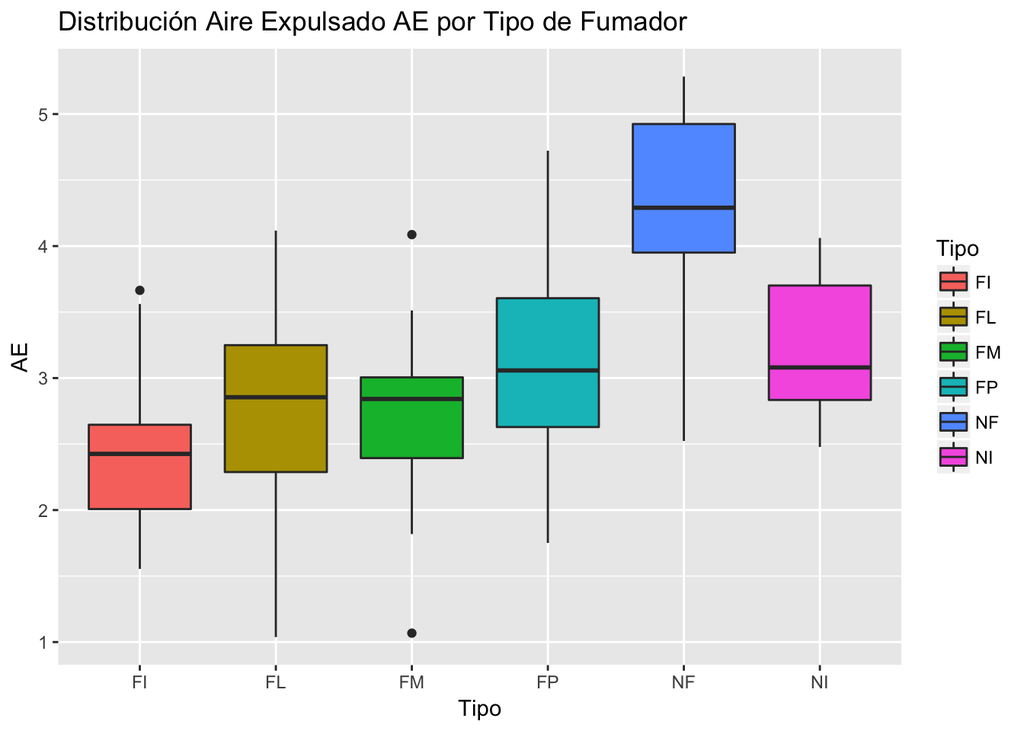

```r
###### - media por tipo de fumador ended ####################

bp <- ggplot(df, aes(x=Tipo, y=AE, fill=Tipo)) + geom_boxplot()
bp + ggtitle("Distribución Aire Expulsado AE por Tipo de Fumador")
```

Se nota la existencia de *outliers* en FI y FM.

# 2. Intervalo de confianza

Calcular el intervalo de confianza de la capacidad pulmonar de toda la muestra. El nivel de confianza es 95 %. Realizar el cálculo manualmente sin usar las funciones t.test o equivalentes. Podéis usar qnorm, qt, pnorm, pt, . . . En cuanto a la elección del método para el cálculo del intervalo de confianza, debéis justificar vuestra elección.

```r
n <- length(df$AE)
m <- mean(df$AE)

conf.level <- 0.95
z <- qt((1+conf.level)/2, df=n-1)
se <- sd(df$AE)/sqrt(n)
ci <- z * se

range_min <- m - ci
range_max <- m + ci

print(paste("Intervalo de confianza: ", range_min, " hasta ", range_max))
```

```
## [1] "Intervalo de confianza:  2.91644216968512  hasta  3.23247715804597"
```

```r
# Confirmando el valor
confirm <- t.test(df$AE, mu=5.0, conf.level = conf.level)
confirm$conf.int
```

```
## [1] 2.916442 3.232477
## attr(,"conf.level")
## [1] 0.95
```

Para calcular el intervalo de confianza he utilizado una formula según Rumsey (2016) [1]:

##### average +- z-score * standardError

Con el uso de la formula de Rumsey (y también confirmado por `t.test`), con 95% de confianza, la cantidad de aire expulsado (AE) está entre 2.9164422 y 3.2324772, con base en el muestreo de datos.

# 3. Comparación de dos muestras: Fumadores vs No Fumadores

¿Podemos afirmar que la capacidad pulmonar de los fumadores es inferior a la de no fumadores? Incluid dentro de la categoría de no fumadores los fumadores pasivos. Realizar el cálculo manualmente sin usar las funciones `t.test` o equivalentes. Podéis usar `qnorm`, `qt`, `pnorm`, `pt` … Seguid los pasos que se indican a continuación.

## 3.1. Escribir la hipótesis nula y alternativa

Al escribir la hipótesis nula y alternativa, si se trata de comprobar si la capacidad pulmonar de los fumadores es inferior a la de no fumadores se debe plantear así:  
**H *<sub>0</sub> : μ <sub>Capac. Fumadores</sub>* = *μ <sub>Capac. No Fumadores</sub>***  
**H *<sub>1</sub> : μ <sub>Capac. Fumadores</sub>* < *μ <sub>Capac. No Fumadores</sub>***

Es decir, se persigue rechazar la hipótesis nula. Al hacerlo, se hace a favor de la alternativa. H0 siempre es la hipótesis nula, y es la que se formula con la igualdad. (*Ester Bernadó Mansilla, orientaciones Tablero*)

## 3.2. Preparar los datos para realizar el contraste

Creando dos data frames que contengan por separado los no fumadores y por otra parte, los fumadores.

```r
nrow(df)
```

```
## [1] 119
```

```r
no_fumadores <- subset(df, df$Tipo =="NF" | df$Tipo == "FI") # NF - No Fumadores / FP - Fumadores pasivos
fumadores <- subset(df, df$Tipo !="NF" & df$Tipo != "FI")
head(no_fumadores)
```

```
##       AE Tipo
## 1 4.0100   NF
## 2 4.8772   NF
## 3 4.2927   NF
## 4 4.9475   NF
## 5 4.1266   NF
## 6 4.1926   NF
```

```r
tail(no_fumadores)
```

```
##         AE Tipo
## 114 2.1986   FI
## 115 2.1249   FI
## 116 2.6047   FI
## 117 2.4378   FI
## 118 2.0082   FI
## 119 3.1654   FI
```

```r
head(fumadores)
```

```
##        AE Tipo
## 20 1.7509   FP
## 21 3.6072   FP
## 22 2.1120   FP
## 23 3.9625   FP
## 24 2.6422   FP
## 25 3.9203   FP
```

```r
tail(fumadores)
```

```
##        AE Tipo
## 94 2.8102   FM
## 95 2.8989   FM
## 96 2.5154   FM
## 97 2.1805   FM
## 98 2.8760   FM
## 99 1.0675   FM
```

```r
n1 <- length( no_fumadores$AE)
n2 <- length( fumadores$AE)
n1
```

```
## [1] 39
```

```r
n2
```

```
## [1] 80
```

```r
s1 <- sd( no_fumadores$AE )
s2 <-sd ( fumadores$AE )
s1
```

```
## [1] 1.130968
```

```r
s2
```

```
## [1] 0.6856958
```

## 3.3. Especificar qué tipo de contraste usaréis

*Podéis consultar Gibergans Baguena (2009).*

Se trata de un **contraste unilateral**, conforme indicado por Baguena (2009) [2], este tipo de contraste es un **contraste de dos muestras sobre la diferencia de medias**.

## 3.4. Realizar los cálculos del valor p

```r
mean1 <- mean( no_fumadores$AE )
mean2 <- mean( fumadores$AE )
mean1
```

```
## [1] 3.325679
```

```r
mean2
```

```
## [1] 2.95199
```

```r
S <- sqrt( s1^2/n1 + s2^2/n2)
zobs <- (mean1-mean2)/ S
zobs
```

```
## [1] 1.9002
```

```r
alfa <- 1-0.95
zcritical <- qnorm( alfa, lower.tail=FALSE )
zcritical
```

```
## [1] 1.644854
```

```r
pvalue <- pnorm( abs(zobs), lower.tail=FALSE )
pvalue
```

```
## [1] 0.02870343
```

## 3.5. Interpretar el resultado del contraste

Observando pvalue = 0.0287034 < α=0.05, rechazamos la hipótesis nula *Capacidad Pulmonar Fumadores = Capacidad Pulmonar No Fumadores* a favor de la hipótesis alternativa.

A partir del valor crítico, también se llega a la misma observación, puesto que el valor observado 1.9002002 > 1.6448536.

# 4. ANOVA

A continuación se realizará un análisis de varianza, donde se desea comparar la capacidad pulmonar entre los seis tipos de fumadores/no fumadores clasificados previamente. El análisis de varianza consiste en evaluar si la variabilidad de una variable dependiente puede explicarse a partir de una o varias variables independientes, denominadas factores. En el caso que nos ocupa, nos interesa evaluar si la variabilidad de la variable AE puede explicarse por el factor tipo de fumador. Hay dos preguntas básicas a responder:

- ¿Existen diferencias entre la capacidad pulmonar (AE) entre los distintos tipos de fumadores/no fumadores?
- Si existen diferencias, ¿entre qué grupos están estas diferencias?

Para la resolución de esta sección, se seguirán los apuntes de López-Roldán y Fachelli (2015).

## 4.1. Verificar la asunción de normalidad

Atendiendo al material, gráfico III. 8.6 y página 25, evaluar si el conjunto de datos cumple las condiciones de aplicación de ANOVA. Seguid los pasos que se indican a continuación.

### 4.1.1. Representar gráficamente la normalidad de la muestra de datos AE con la función qqnorm

```r
NF <- df[df$Tipo == "NF", c("AE")]
FP <- df[df$Tipo == "FP", c("AE")]
NI <- df[df$Tipo == "NI", c("AE")]
FL <- df[df$Tipo == "FL", c("AE")]
FM <- df[df$Tipo == "FM", c("AE")]
FI <- df[df$Tipo == "FI", c("AE")]
sum(length(NF), length(FP), length(NI), length(FL), length(FM),length(FI))
```

```
## [1] 119
```

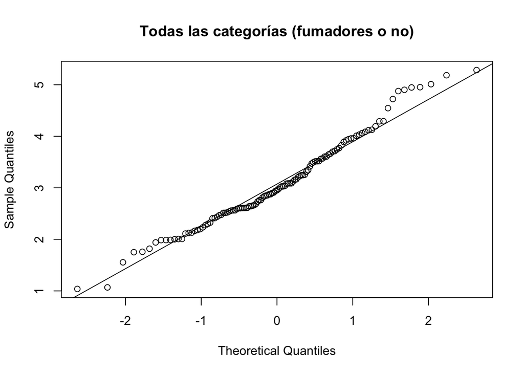

```r
qqnorm(df$AE, main = "Todas las categorías (fumadores o no)")
qqline(df$AE)
```

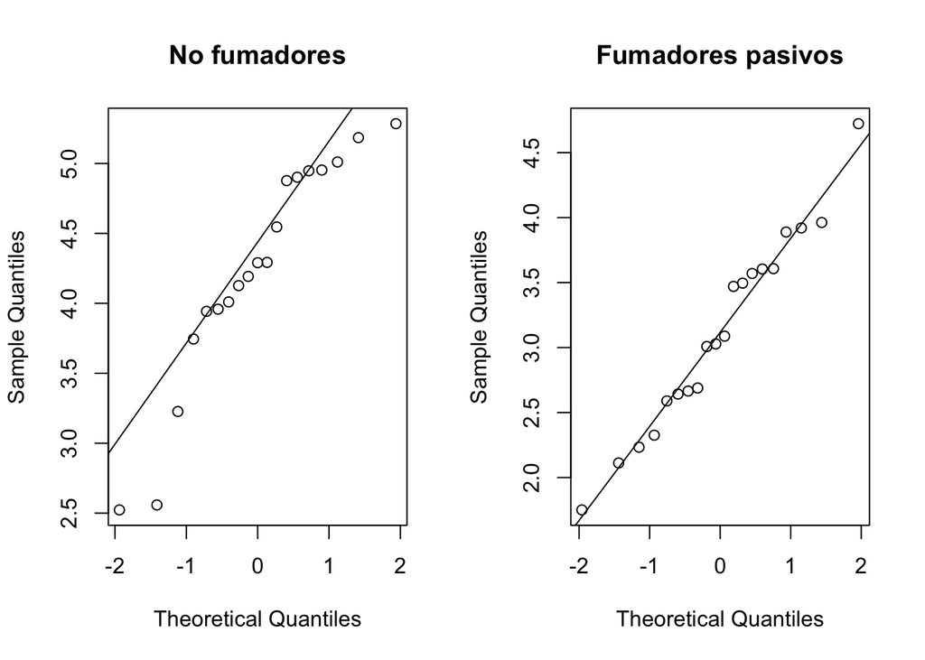

```r
par( mfrow=c(1,2))
qqnorm(NF, main = "No fumadores")
qqline(NF)
qqnorm(FP, main = "Fumadores pasivos")
qqline(FP)
```

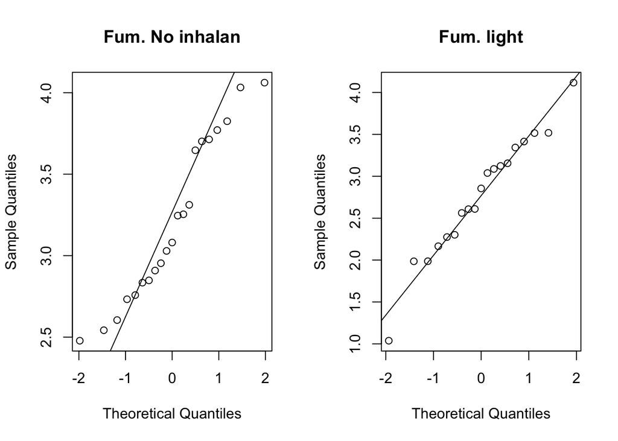

```r
qqnorm(NI, main = "Fum. No inhalan")
qqline(NI)
qqnorm(FL, main = "Fum. light")
qqline(FL)
```

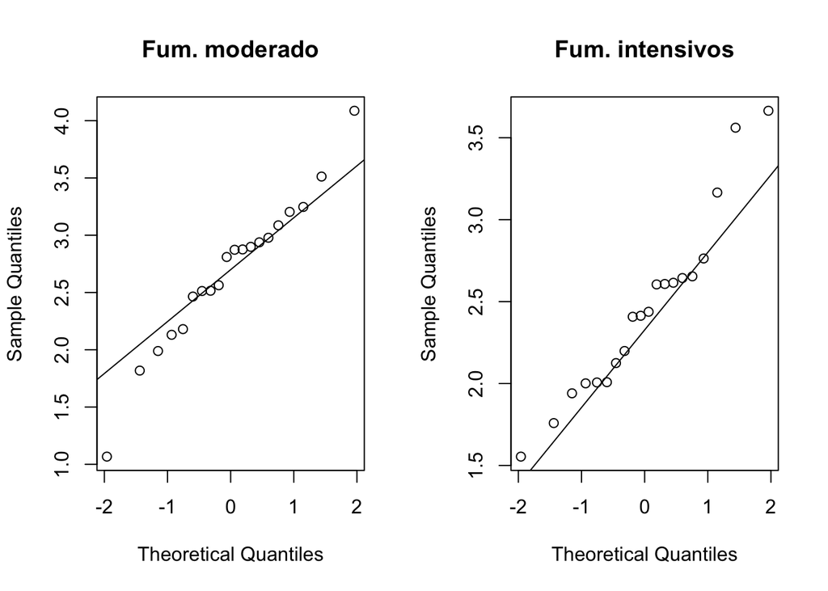

```r
qqnorm(FM, main = "Fum. moderado")
qqline(FM)
qqnorm(FI, main = "Fum. intensivos")
qqline(FI)
```

```r
par( mfrow=c(1,1))
```

### 4.1.2. Escribir la hipótesis nula e hipótesis alternativa

**H *<sub>0</sub> : La distribución es normal***  
**H *<sub>1</sub> : La distribución no es normal***

Según López-Roldán y Fachelli (2015) [3], para determinar la **condición de normalidad** se aplica una prueba estadística que la determina como la prueba de *Kolmogorov-Smirnov*, u otras como las de *Lilliefors*, *Anderson-Darling* o *Shapiro-Wilk*.

### 4.1.3. Aplicar un test de normalidad

*Aplicar un test de normalidad, siguiendo las recomendaciones del material mencionado López-Roldán y Fachelli (2015). Justificar la elección.*

```r
test_and_define_if_normal <- function(x) {
  sr <- shapiro.test(x)

  #valor de significación = alpha <- 0.05
  print(paste(ifelse(sr$p.value >= alfa, "Distribución Normal", "Distribución no normal"), "- p-value: ", sr$p.value))
}


# Son solamente 6 atributos, si fueran mas estableceria un algoritmo, por ejemplo para aplicar todo de golpe con lappy en un dataset
test_and_define_if_normal(NF)
```

```
## [1] "Distribución Normal - p-value:  0.070612071217006"
```

```r
test_and_define_if_normal(FP)
```

```
## [1] "Distribución Normal - p-value:  0.875683996959829"
```

```r
test_and_define_if_normal(NI)
```

```
## [1] "Distribución Normal - p-value:  0.157819847904823"
```

```r
test_and_define_if_normal(FL)
```

```
## [1] "Distribución Normal - p-value:  0.803612711400276"
```

```r
test_and_define_if_normal(FM)
```

```
## [1] "Distribución Normal - p-value:  0.793198135620242"
```

```r
test_and_define_if_normal(FI)
```

```
## [1] "Distribución Normal - p-value:  0.254249135275093"
```

La justificativa de mí elección ha sido porque individualmente los conjuntos de datos son de menos de 30 ítems y, aún siguiendo a López-Roldán y Fachelli (2015) [3] si n≤30 se tiene que verificar con la prueba estadística de normalidad de *Shapiro-Wilk*.

### 4.1.4. Interpretar los resultados a partir del gráfico qqnorm y de los valores que devuelve el test.

Tomando el valor de significación α= 0.05 y su comparación con los valores de p-value de los resultados del apartado anterior, podríamos definir que se trata de muestreos de distribución normal. Lo mismo puede ser encontrado si miramos en los gráficos donde también se puede observar la tendencia de seguir la línea trazada por `qqline`.

## 4.2. Homoscedasticidad: Homogeneidad de varianzas

Otra de las condiciones de aplicación de ANOVA es la igualdad de varianzas (homoscedasticidad). Aplicar un test para validar si los grupos presentan igual varianza. Seguid las indicaciones de los apuntes de López-Roldán y Fachelli (2015).

### 4.2.1. Escribir hipótesis nula y alternativa

**H *<sub>0</sub> : Las varianzas poblacionales son iguales (homoscedasticidad) $\sigma_{1}^2$ = $\sigma_{2}^2$***  
**H *<sub>1</sub> : Las varianzas poblacionales son distintas (heteroscedasticidad) $\sigma_{1}^2$ $\neq$ $\sigma_{2}^2$***

### 4.2.2. Realizar los cálculos

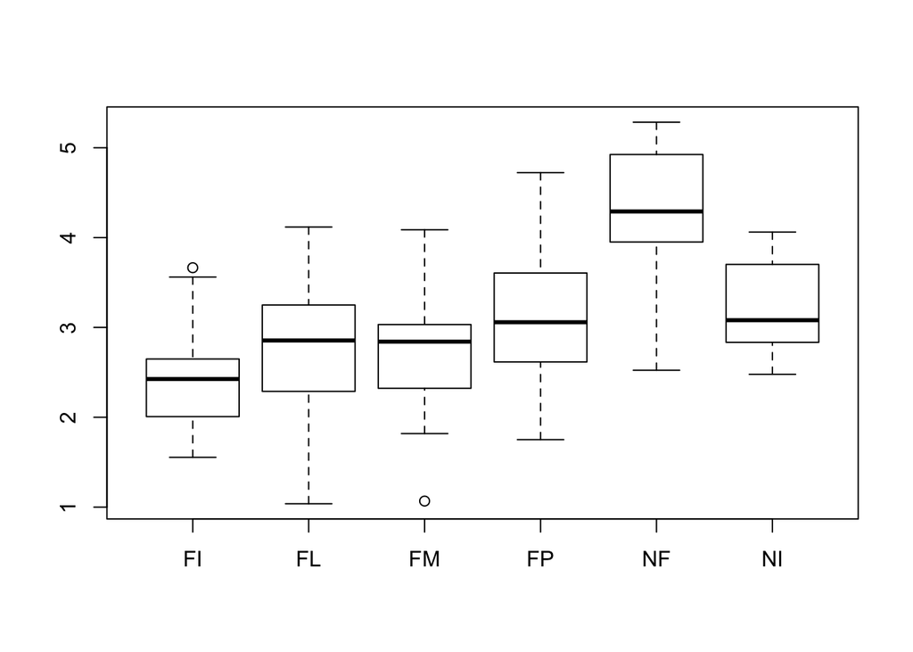

```r
boxplot(df$AE~df$Tipo)
```

```r
bart <- bartlett.test(df$AE~df$Tipo)
bart
```

```
##
##  Bartlett test of homogeneity of variances
##
## data:  df$AE by df$Tipo
## Bartlett's K-squared = 6.0904, df = 5, p-value = 0.2975
```

```r
# Probando tambien con Levene test
library(lawstat)
levene.test(df$AE, df$Tipo)
```

```
##
##  modified robust Brown-Forsythe Levene-type test based on the
##  absolute deviations from the median
##
## data:  df$AE
## Test Statistic = 0.99701, p-value = 0.4229
```

### 4.2.3. Interpretar los resultados

Para el análisis e interpretación de los resultados, seguimos con las orientaciones de Dragonfly Statistics (2013) [4], primero, mirando los box plots, notamos que la formas / tamaños de las cajas son aproximadamente los mismos, dando un inidicio que tenemos un muestreo donde la varianza es homogénea. Nosotros rejectamos la hipótesis nula si p-valor fuera < 0.05, sin embargo, el resultado del **Bartlett test** nos enseña 0.2975217 > 0.05. Por lo tanto, aceptamos la hipótesis nula.

## 4.3. ANOVA unifactorial (One Way ANOVA)

Calcular ANOVA de un factor (one-way ANOVA o independent samples ANOVA) para investigar si existen diferencias en el nivel de aire expulsado (AE) entre los distintos tipos de fumadores.

### 4.3.1. Escribir la hipótesis nula y alternativa

ANOVA unifactorial compara las medias entre los grupos que nos interesan y determina si alguna de esas medias es, en términos estadísticos, significativamente diferente entre sí. Específicamente, prueba la hipótesis nula:

**H *<sub>0</sub> : μ <sub>NF</sub> = μ <sub>FP</sub> = μ <sub>NI</sub> = μ <sub>FL</sub> = μ <sub>FM</sub> = μ <sub>FI</sub>***  
**H *<sub>1</sub> : μ <sub>al menos 2 grupos son significativamente $\neq$ entre sí</sub>***

### 4.3.2. Realizar los cálculos

Podéis usar la función **aov.**

```r
anova <- aov(df$AE~df$Tipo, df)
anova
```

```
## Call:
##    aov(formula = df$AE ~ df$Tipo, data = df)
##
## Terms:
##                  df$Tipo Residuals
## Sum of Squares  38.58845  50.82225
## Deg. of Freedom        5       113
##
## Residual standard error: 0.6706373
## Estimated effects may be unbalanced
```

```r
summary(anova)
```

```
##              Df Sum Sq Mean Sq F value   Pr(>F)
## df$Tipo       5  38.59   7.718   17.16 1.33e-12 ***
## Residuals   113  50.82   0.450
## ---
## Signif. codes:  0 '***' 0.001 '**' 0.01 '*' 0.05 '.' 0.1 ' ' 1
```

```r
TukeyHSD(anova)
```

```
##   Tukey multiple comparisons of means
##     95% family-wise confidence level
##
## Fit: aov(formula = df$AE ~ df$Tipo, data = df)
##
## $`df$Tipo`
##              diff         lwr        upr     p adj
## FL-FI  0.31717895 -0.30570727  0.9400652 0.6799755
## FM-FI  0.23127500 -0.38357364  0.8461236 0.8842366
## FP-FI  0.66219000  0.04734136  1.2770386 0.0269550
## NF-FI  1.78410526  1.16121904  2.4069915 0.0000000
## NI-FI  0.74969048  0.14220556  1.3571754 0.0066297
## FM-FL -0.08590395 -0.70879017  0.5369823 0.9986515
## FP-FL  0.34501105 -0.27787517  0.9678973 0.5964475
## NF-FL  1.46692632  0.83610492  2.0977477 0.0000000
## NI-FL  0.43251153 -0.18310712  1.0481302 0.3283395
## FP-FM  0.43091500 -0.18393364  1.0457636 0.3310706
## NF-FM  1.55283026  0.92994404  2.1757165 0.0000000
## NI-FM  0.51841548 -0.08906944  1.1259004 0.1406800
## NF-FP  1.12191526  0.49902904  1.7448015 0.0000120
## NI-FP  0.08750048 -0.51998444  0.6949854 0.9983381
## NI-NF -1.03441479 -1.65003343 -0.4187961 0.0000527
```

### 4.3.3. Interpretar los resultados de la prueba ANOVA y relacionarlos con el resultado gráfico del boxplot

Como el *p-value* es menor que el nivel de significación α = 0.05, podemos concluir que hay diferencias significativas entre los grupos resaltados con “*" en el `summary` del modelo.

Utilizamos también un TukeyHSD para realizar múltiples *pairwise-comparison* entre las medias de los grupos y sumadas también al análisis anterior de los *box plots* podemos decir que se nota que hay $\neq$ significativas entre categorías como, por ejemplo, NF-FI (No fumantes y Fumantes intensos).

## 4.4. Cálculos ANOVA

### 4.4.1. Identificar las variables

A partir de los resultados del modelo devuelto por `aov`, identificar las variables SST (Total Sum of Squares), SSW (Within Sum of Squares), SSB (Between Sum of Squares) y los grados de libertad. A partir de estos valores, calcular manualmente el valor F, el valor crítico (a un nivel de confianza del 95%), y el valor p.Interpretar los resultados.

```r
sumSq <- summary(anova)[[1]]$'Sum Sq'

#Manera 1
print(paste("SSW (Within Sum of Squares):",sumSq[2]))
```

```
## [1] "SSW (Within Sum of Squares): 50.8222519546478"
```

```r
#Manera 2
SSW.aov <- sum( anova$residuals ^ 2 )
SSW.aov
```

```
## [1] 50.82225
```

```r
SSB.aov <- sumSq[1]
print(paste("SSB (Between Sum of Squares):", SSB.aov))
```

```
## [1] "SSB (Between Sum of Squares): 38.5884504717387"
```

```r
SST.aov <- sum(sumSq)
SST.aov
```

```
## [1] 89.4107
```

```r
grados_libertad <- summary(anova)[[1]]$'Df'
grados_libertad
```

```
## [1]   5 113
```

```r
k <- 6  #grupos
N <-length( df$AE )
N
```

```
## [1] 119
```

```r
F <- (SSB.aov / (k-1)) / (SSW.aov/ (N-k))
F
```

```
## [1] 17.15979
```

```r
valor_critico <- qf(1 - alfa, grados_libertad[1], grados_libertad[2])
valor_critico
```

```
## [1] 2.29463
```

```r
p_value <- summary(anova)[[1]][["Pr(>F)"]]
p_value[1]
```

```
## [1] 1.332457e-12
```

El anova unifactorial (Oneway ANOVA) ha enseñado un efecto significativo para categorías de fumadores con relación a capacidad pulmonar, F(5, 113) = 17.1597863, p < 0.05 -> 1.332456610^{-12}< 0.05. En otras palabras, podemos rejectar la hipótesis nula de que todos los tipos / categorías de fumadores tienen capacidad pulmonor igual.

### 4.4.2. Calcular manualmente las variables

Calcular manualmente SSB, SSW y SST a partir de los datos de la muestra. Comprobad que el cálculo coincide con los valores que devuelve la función anova. Las funciones summarize y group_by os pueden ser útiles para simplificar los cálculos.

```r
varNF <- sum ((NF - mean(NF)) ^ 2 )
varFP <- sum ((FP - mean(FP)) ^ 2 )
varNI <- sum ((NI - mean(NI)) ^ 2 )
varFL <- sum ((FL - mean(FL)) ^ 2 )
varFM <- sum ((FM - mean(FM)) ^ 2 )
varFI <- sum ((FI - mean(FI)) ^ 2 )

#SSW (Within Sum of Squares): varianza intra grupo
SSW <- varNF + varFP + varNI + varFL + varFM + varFI
SSW
```

```
## [1] 50.82225
```

```r
#SST (Total Sum of Squares): varianza total
SST <- sum( (df$AE - mean(df$AE)) ^ 2 )
SST
```

```
## [1] 89.4107
```

```r
# SSB (Between Sum of Squares): Varianza entre grupos
SSB <- SST - SSW
SSB
```

```
## [1] 38.58845
```

```r
#Comparando los valores extraidos del anova con los calculados
kable(data.frame("Metodo de obtención" = c("Extraído del `aov()`", "Calculado Manualmente")
                 , "SSW" = c(format(round(SSW.aov, 2), nsmall = 2), format(round(SSW, 2), nsmall = 2))
                 , "SSB" = c(format(round(SSB.aov, 2), nsmall = 2), format(round(SSB, 2), nsmall = 2))
                 , "SST" = c(format(round(SST.aov, 2), nsmall = 2), format(round(SST, 2), nsmall = 2))))
```

| Metodo.de.obtención | SSW | SSB | SST |
| --- | --- | --- | --- |
| Extraído del `aov()` | 50.82 | 38.59 | 89.41 |
| Calculado Manualmente | 50.82 | 38.59 | 89.41 |

Conforme hemos visto en la comprobación, los resultados han coincidido.

## 4.5. Calcular la fuerza de la relación e interpretar el resultado

Podéis consultar López-Roldán y Fachelli (2015), p.37.

```r
library(lsr)
etaS <- etaSquared(anova)
etaS
```

```
##            eta.sq eta.sq.part
## df$Tipo 0.4315865   0.4315865
```

```r
summary.lm(anova)
```

```
##
## Call:
## aov(formula = df$AE ~ df$Tipo, data = df)
##
## Residuals:
##     Min      1Q  Median      3Q     Max
## -1.7360 -0.4516 -0.0187  0.4871  1.6038
##
## Coefficients:
##             Estimate Std. Error t value Pr(>|t|)
## (Intercept)   2.4565     0.1500  16.381  < 2e-16 ***
## df$TipoFL     0.3172     0.2148   1.476 0.142643
## df$TipoFM     0.2313     0.2121   1.091 0.277796
## df$TipoFP     0.6622     0.2121   3.122 0.002278 **
## df$TipoNF     1.7841     0.2148   8.304 2.45e-13 ***
## df$TipoNI     0.7497     0.2095   3.578 0.000511 ***
## ---
## Signif. codes:  0 '***' 0.001 '**' 0.01 '*' 0.05 '.' 0.1 ' ' 1
##
## Residual standard error: 0.6706 on 113 degrees of freedom
## Multiple R-squared:  0.4316, Adjusted R-squared:  0.4064
## F-statistic: 17.16 on 5 and 113 DF,  p-value: 1.332e-12
```

Como ha sido definido por López-Roldán y Fachelli (2015) [3], estos datos representán la variabilidad explicada sobre la variabilidad total. El valor obtenido queda entre 0 y 1 midiendo la parte explicada por la variable independiente.

En nuestro muestreo se obtiene un valor del **0.4315865**.

# 5. Comparaciones múltiples

Independientemente del resultado obtenido en el apartado anterior, realizamos un test de comparación múltiple entre los grupos. Este test se aplica cuando el test ANOVA devuelve rechazar la hipótesis nula de igualdad de medias. Por tanto, procederemos como si el test ANOVA hubiera dado como resultado el rechazo de la hipótesis nula.

## 5.1. Sin corrección

Calcular las comparaciones entre grupos sin ningún tipo de corrección. Podéis usar la función pairwise.t.test.

```r
pairwise.t.test(df$AE, df$Tipo, p.adj = "none")
```

```
##
##  Pairwise comparisons using t tests with pooled SD
##
## data:  df$AE and df$Tipo
##
##    FI      FL      FM      FP      NF
## FL 0.14264 -       -       -       -
## FM 0.27780 0.69003 -       -       -
## FP 0.00228 0.11110 0.04451 -       -
## NF 2.5e-13 6.9e-10 6.2e-11 8.2e-07 -
## NI 0.00051 0.04400 0.01484 0.67704 3.6e-06
##
## P value adjustment method: none
```

## 5.2. Corrección de Bonferroni

Aplicar la corrección de Bonferroni en la comparación múltiple. Interpretar el resultado y contrastar el resultado con el obtenido sin corrección.

```r
pairwise.t.test(df$AE, df$Tipo, p.adj = "bonferroni")
```

```
##
##  Pairwise comparisons using t tests with pooled SD
##
## data:  df$AE and df$Tipo
##
##    FI      FL      FM      FP      NF
## FL 1.0000  -       -       -       -
## FM 1.0000  1.0000  -       -       -
## FP 0.0342  1.0000  0.6676  -       -
## NF 3.7e-12 1.0e-08 9.3e-10 1.2e-05 -
## NI 0.0077  0.6600  0.2226  1.0000  5.5e-05
##
## P value adjustment method: bonferroni
```

Usando el ajuste de **Bonferroni**, solo la comparación NF - * y FI - {FP, NF o NI} son estadísticamente significativas. Tenga en cuenta que estos resultados son más conservadores que sin ningún ajuste. Por ejemplo, **sin ajustes** la comparación NI - {FL o FM} también era considerada significativa.

## 5.3. Prueba de Scheffé

La prueba de Scheffé es una de las más usadas cuando se cumplen condiciones de igualdad de varianza. Según López, está basada en la distribución F. Permite la comparación binaria entre pares de medias y también la comparación múltiple. En las comparaciones de pares es conservadora. Se puede aplicar con muestras de tamaño desigual y es bastante robusta ante el incumplimiento de la condición de homoscedasticidad.

Aplicad la prueba de Scheffé e interpretar el resultado.

```r
library(agricolae)
scheffe.test(anova,"df$Tipo", group=FALSE,console=TRUE, main="Capacidad Pulmonar de Fumadores y no fumadores")
```

```
##
## Study: Capacidad Pulmonar de Fumadores y no fumadores
##
## Scheffe Test for df$AE
##
## Mean Square Error  : 0.4497544
##
## df$Tipo,  means
##
##       df.AE       std  r    Min    Max
## FI 2.456500 0.5515356 20 1.5541 3.6645
## FL 2.773679 0.7182298 19 1.0377 4.1173
## FM 2.687775 0.6575152 20 1.0675 4.0868
## FP 3.118690 0.7497423 20 1.7509 4.7225
## NF 4.240605 0.8100596 19 2.5231 5.2844
## NI 3.206190 0.5025607 21 2.4779 4.0616
##
## Alpha: 0.05 ; DF Error: 113
## Critical Value of F: 2.29463
##
## Comparison between treatments means
##
##          Difference pvalue sig        LCL        UCL
## FI - FL -0.31717895 0.8227     -1.2013452  0.5669873
## FI - FM -0.23127500 0.9450     -1.1040322  0.6414822
## FI - FP -0.66219000 0.0916   . -1.5349472  0.2105672
## FI - NF -1.78410526 0.0000 *** -2.6682715 -0.8999390
## FI - NI -0.74969048 0.0311   * -1.6119951  0.1126141
## FL - FM  0.08590395 0.9995     -0.7982623  0.9700702
## FL - FP -0.34501105 0.7639     -1.2291773  0.5391552
## FL - NF -1.46692632 0.0000 *** -2.3623563 -0.5714964
## FL - NI -0.43251153 0.5311     -1.3063617  0.4413386
## FM - FP -0.43091500 0.5339     -1.3036722  0.4418422
## FM - NF -1.55283026 0.0000 *** -2.4369965 -0.6686640
## FM - NI -0.51841548 0.3024     -1.3807201  0.3438891
## FP - NF -1.12191526 0.0002 *** -2.0060815 -0.2377490
## FP - NI -0.08750048 0.9993     -0.9498051  0.7748041
## NF - NI  1.03441479 0.0006 ***  0.1605646  1.9082650
```

La segunda tabla de resultados proporciona la comparación por pares de las medias para todas las posibles combinaciones de grupos. La comparación debe hacerse en la columna ‘Difference’ de la segunda tabla con el ‘Valor crítico de F’, y los valores p se generan en función de eso. Simplemente verificamos la columna p-value, si es menor que 0.05, indica que la media para los dos grupos es diferente.

# 6. ANOVA multifactorial

En una segunda fase de la investigación se evaluó el efecto del sexo como variable independiente. Con este objetivo, se recolectó un segundo conjunto de datos con las variables independientes sexo y nivel de fumador y con la variable dependiente capacidad pulmonar medida según el aire expulsado, al igual que con el primer conjunto de datos. Este conjunto de datos se encuentra en el fichero `Fumadores2.csv`.

## 6.1. Estudiar los efectos principales y posibles interacciones

Examinar las características del conjunto de datos y realizar un estudio visual de los datos. A continuación, aplicad ANOVA. Seguid los pasos que se indican a continuación.

### 6.1.1. Análisis visual

Se realizará un primer estudio visual para determinar si sólo existen efectos principales o hay efectos de interacción entre sexo y tipo de fumador. Para ello, seguir los pasos que se indican a continuación:

#### 1.

Leer el conjunto de datos

```r
df2 <- read.csv("data/Fumadores2.csv")
head(df2)
```

```
##         AE Tipo Sex
## 1 3.607107   NF   M
## 2 3.708264   NF   M
## 3 3.824298   NF   M
## 4 3.355296   NF   M
## 5 3.921486   NF   M
## 6 3.195607   NF   M
```

```r
# Buscando por valores NA
print(unlist(lapply(df2, function(x) any(is.na(x)))))
```

```
##    AE  Tipo   Sex
## FALSE FALSE FALSE
```

```r
# Reunindo los tipos de variables e imprimindo
res2 <- sapply(df2, class)
kable(data.frame(variables=names(res2),clase=as.vector(res2)))
```

| variables | clase |
| --- | --- |
| AE | numeric |
| Tipo | factor |
| Sex | factor |

```r
summary(df2)
```

```
##        AE         Tipo     Sex
##  Min.   :0.5306   FI: 54   F:252
##  1st Qu.:2.6642   FL: 62   M:250
##  Median :3.2370   FM: 46
##  Mean   :3.1329   FP:100
##  3rd Qu.:3.6826   NF:100
##  Max.   :5.3123   NI:140
```

```r
unique(df2$Tipo)
```

```
## [1] NF FP NI FL FM FI
## Levels: FI FL FM FP NF NI
```

```r
unique(df2$Sex)
```

```
## [1] M F
## Levels: F M
```

#### 2.

Agrupar el conjunto de datos por tipo de fumador y sexo y calcular la media de AE en cada grupo. Podéis usar las instrucciones `group_by` y `summarise` de la librería `dplyr` para realizar este proceso. Mostrar el conjunto de datos en forma de tabla, donde se muestre la media de cada grupo según el sexo y tipo de fumador.

```r
library(magrittr)
library(dplyr)
attach(df2)
fum2 <- df2 %>%
  select(AE, Tipo, Sex) %>%
  group_by(Tipo, Sex) %>%
  summarise(AE = mean(AE))

kable(fum2)
```

| Tipo | Sex | AE |
| --- | --- | --- |
| FI | F | 2.153394 |
| FI | M | 2.486166 |
| FL | F | 2.743544 |
| FL | M | 3.037663 |
| FM | F | 2.282694 |
| FM | M | 2.574741 |
| FP | F | 3.301332 |
| FP | M | 3.406332 |
| NF | F | 3.641762 |
| NF | M | 3.748391 |
| NI | F | 3.163780 |
| NI | M | 3.292063 |

#### 3.

Mostrar en un plot el valor de AE medio para cada tipo de fumador y sexo. Podéis inspiraros en los gráficos de López-Roldán y Fachelli (2015), p.38. Podéis realizar este tipo de gráfico usando la función `ggplot` de la librería `ggplot2`.

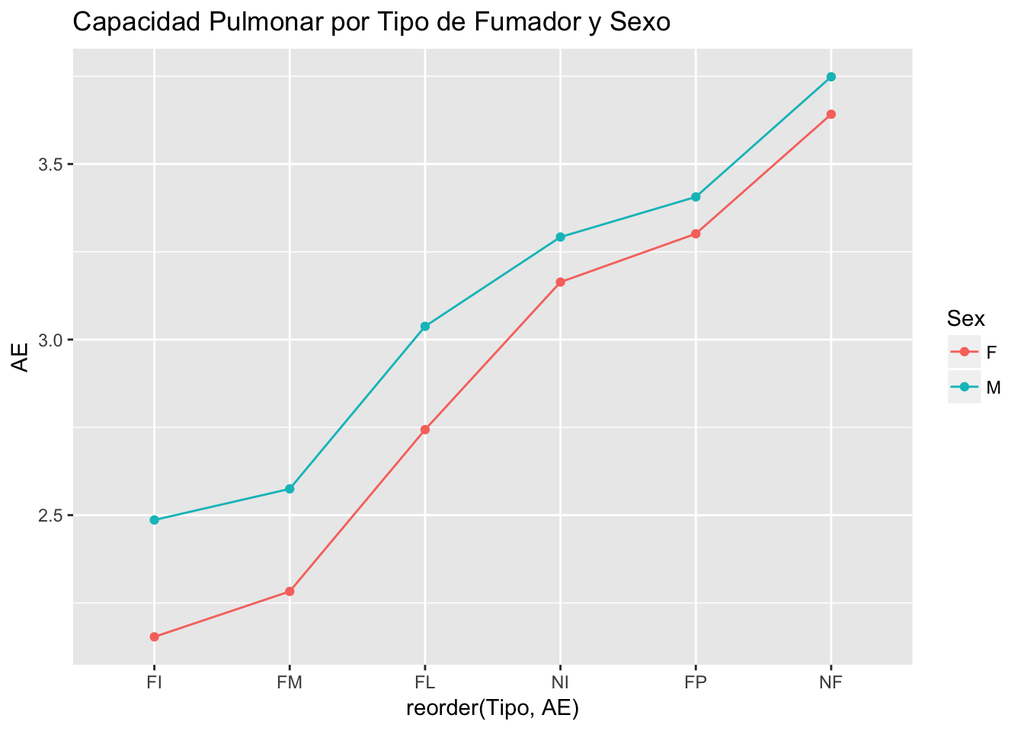

```r
ggplot(data=fum2, aes(x=reorder(Tipo, AE), y=AE, group=Sex)) +
  geom_line(aes(color=Sex))+
  geom_point(aes(color=Sex))+
  labs(title="Capacidad Pulmonar por Tipo de Fumador y Sexo")
```

#### 4.

Interpretar el resultado sobre si existen sólo efectos principales o existe interacción. Si existe interacción, explicar cómo se observa y qué efectos produce esta interacción.

Para quedar 100% claro sobre los efectos con y sin interacción, voy a usar una imagen bastante interesante de López-Roldán y Fachelli (2015).

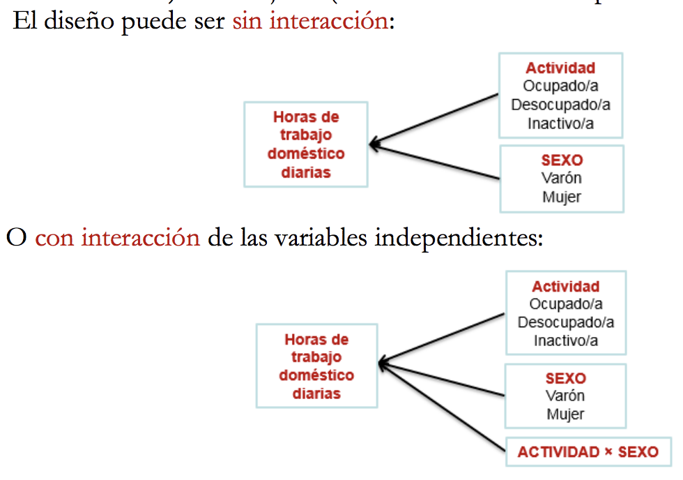

### 6.1.2. ANOVA multifactorial

Calcular ANOVA multifactorial para evaluar si la variable dependiente AE se puede explicar a partir de las variables independientes sexo y tipo de fumador. Incluid el efecto de la interacción sólo si se ha observado dicha interacción en el análisis visual del apartado anterior. Interpretad el resultado.

```r
anova2 <- aov(AE ~ Tipo + Sex, data = df2)
summary(anova2)
```

```
##              Df Sum Sq Mean Sq F value  Pr(>F)
## Tipo          5 100.05  20.009  37.456 < 2e-16 ***
## Sex           1   3.92   3.922   7.343 0.00697 **
## Residuals   495 264.43   0.534
## ---
## Signif. codes:  0 '***' 0.001 '**' 0.01 '*' 0.05 '.' 0.1 ' ' 1
```

De la tabla ANOVA podemos concluir que tanto `Tipo` como `Sex` son estadísticamente significativas. El `Tipo` es la variable de factor más significativa. Estos resultados nos llevarían a pensar que los cambios en los Tipos de fumadores (esto es, la persona que deja de ser un Fumador Intensivo para ser un NI - No Inhalan) es definitivamente el más significativo, sin embargo hay también que considerar que el sexo de la persona influye y afectará significativamente en la cantidad de Aire Expulsado / Capacidad Pulmonar.

# Referencias

[1] **Rumsey, D. (2016)** *“How to calculate a confidence interval for a population mean when you know its standard deviation”*. [artículo en línea]. [Fecha de consulta: 06 de junio del 2018]. http://www.dummies.com/education/math/statistics/how-to-calculate-a-confidence-interval-for-a-population-mean-when-you-know-its-standard-deviation/

[2] **Baguena, J. (2009)** *“Contraste de Dos Muestras.”* In Estadística, edited by Josep Gibergans Baguena, Angel J. Gil Estallo, and Carles Rovira Escofet. Barcelona: FUOC.

[3] **López-Roldán, P. y Fachelli, S. (2015)** *“Metodología de la Investigación Social Cuantitativa”* 1ª edición, Barcelona: Universitat Autònoma de Barcelona. [artículo en línea]. [Fecha de consulta: 10 de junio del 2018]. https://ddd.uab.cat/pub/caplli/2016/163568/metinvsoccua_cap3-8a2016.pdf

[5] **Quick, J. (2011)** *“R Tutorial Series: ANOVA Pairwise Comparison Methods”* [artículo en línea]. [Fecha de consulta: 13 de junio del 2018]. https://www.r-bloggers.com/r-tutorial-series-anova-pairwise-comparison-methods/